# Making effective graphs

## Outline

- What makes a good graph?
- What makes a good series of graphs?
- What graphical elements are appropriate for different types of data?

## What makes a good graph?

## Graph from last time

- What makes this a good graph?
- What makes this a bad graph?

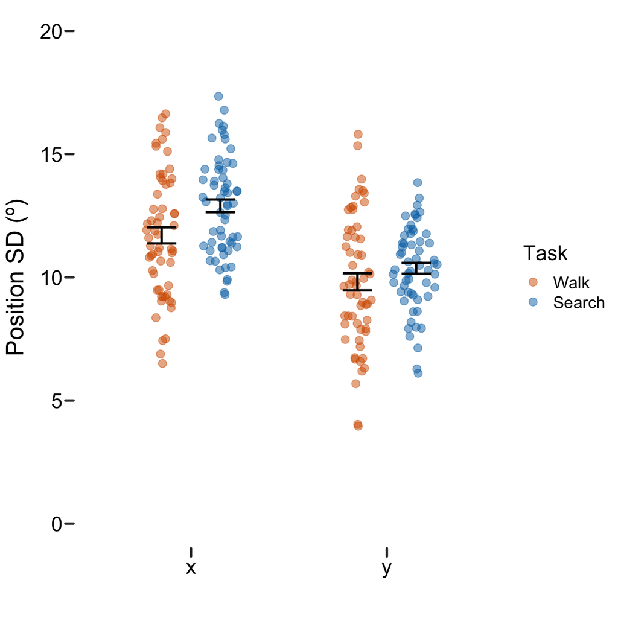

## How about this one?

- What makes this a good graph?
- What makes this a bad graph?

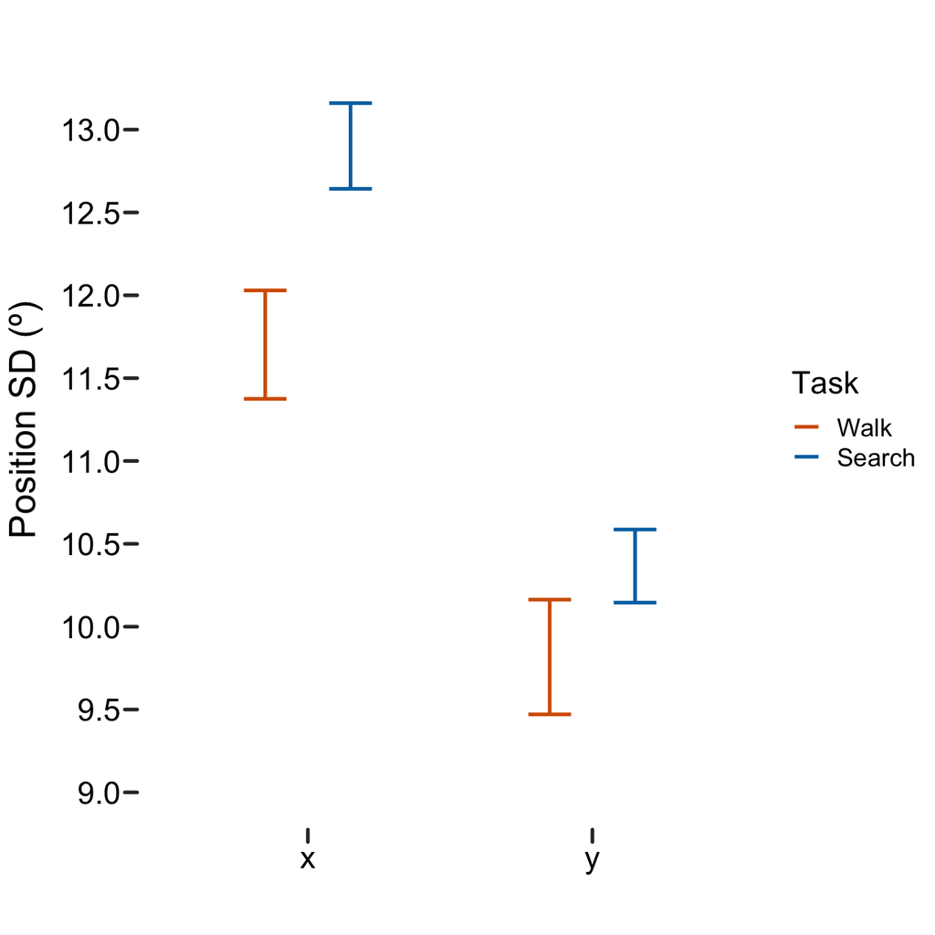

## How about this one?

- What makes this a good graph?
- What makes this a bad graph?

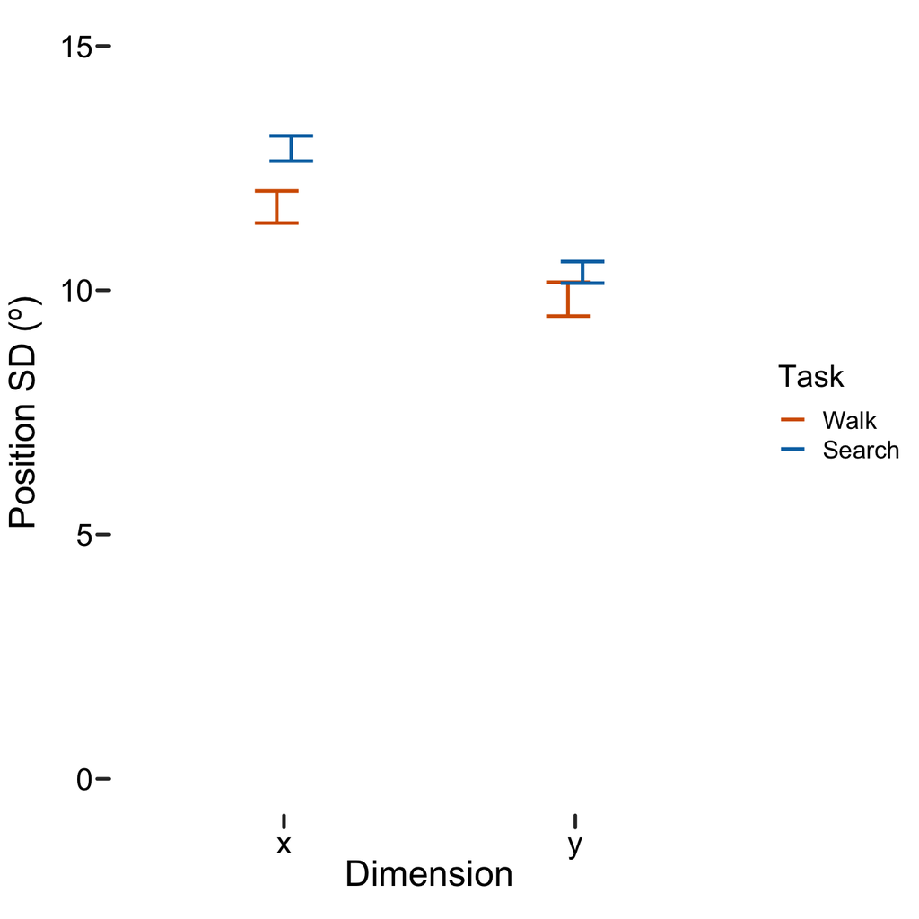

## How about this one?

- What makes this a good graph?
- What makes this a bad graph?

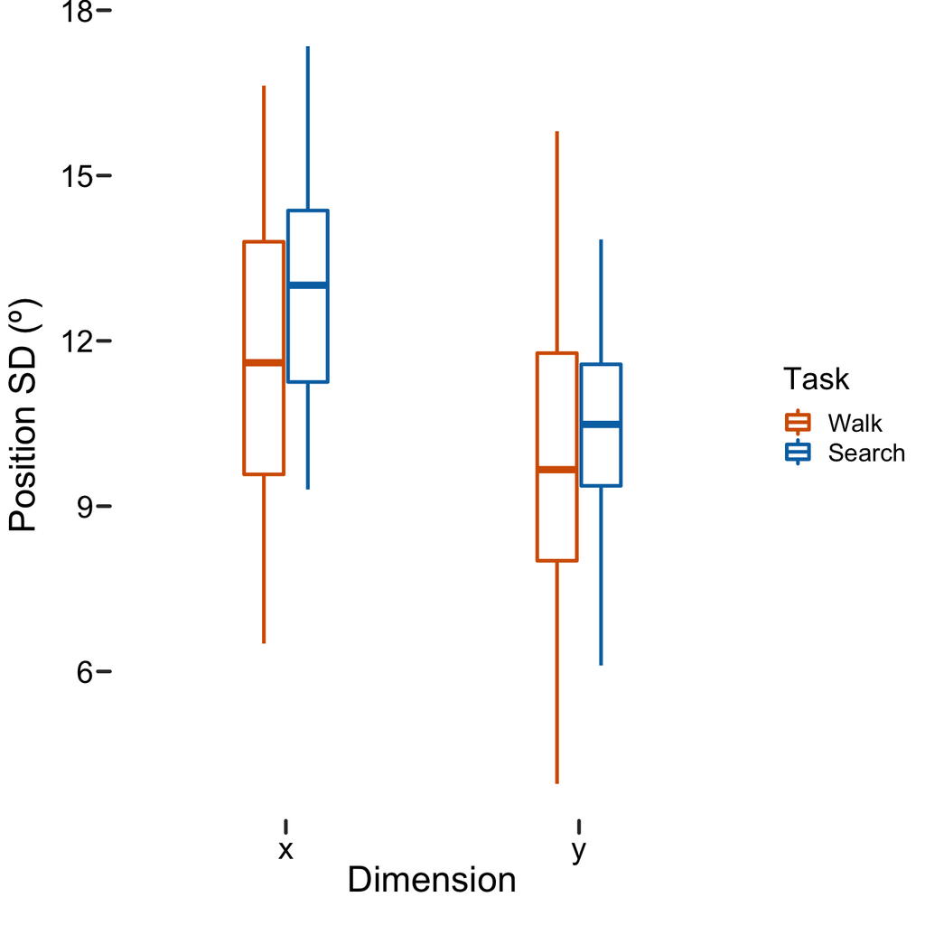

## How about this one?

- What makes this a good graph?
- What makes this a bad graph?

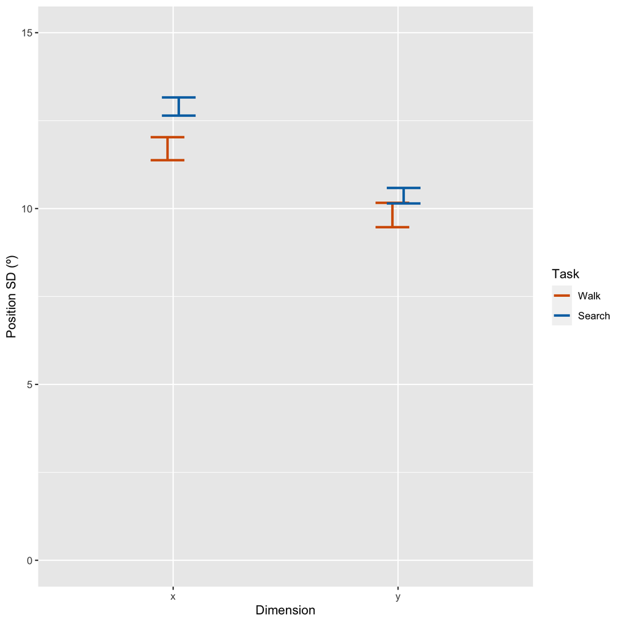

## Making effective visualizations

- What makes a good graph?
  - Highlights the most important information
  - Reduces visual clutter (remove unnecessary backgrounds, lines, etc)
  - Clear, legible elements (text is big enough, colors/shapes are distinguishable)
  - Graphical elements map onto conceptual elements (graph mean +/- SE if showing inferential statistics, don’t show min/max if it’s not relevant)
  - Graph does not mislead the audience (sensible axes, all data included)
  - Scaffolds for interpreting figure (annotations, reference lines, scales)

## What makes a series of graphs?

## How about this one?

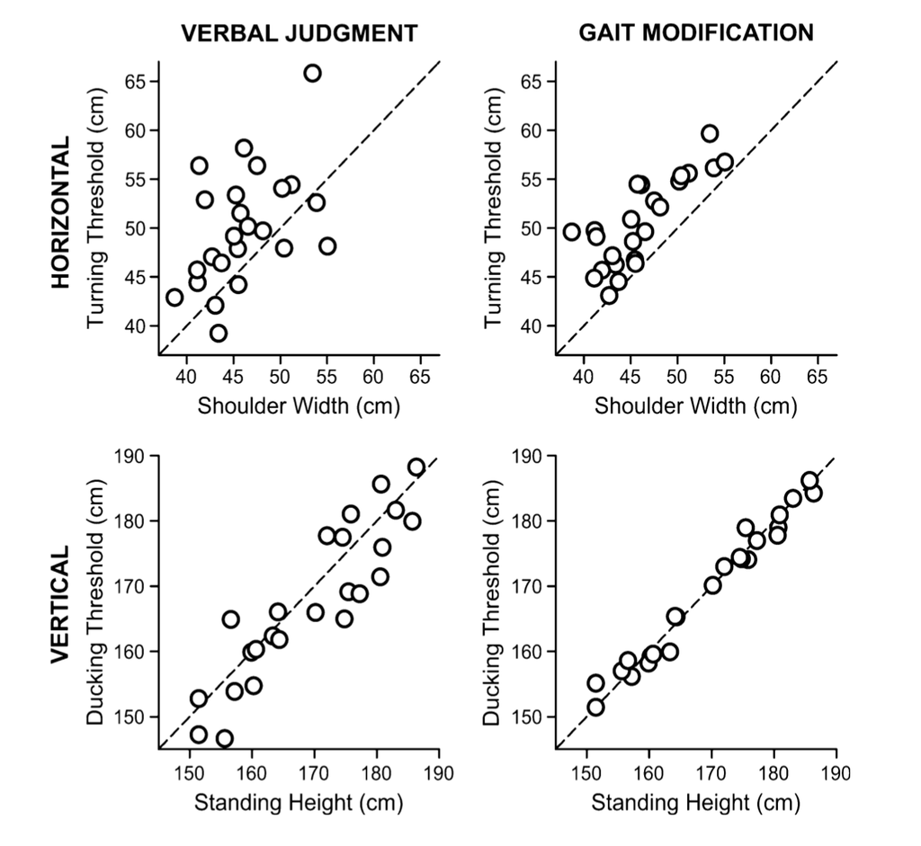

## If could go back and fix it…

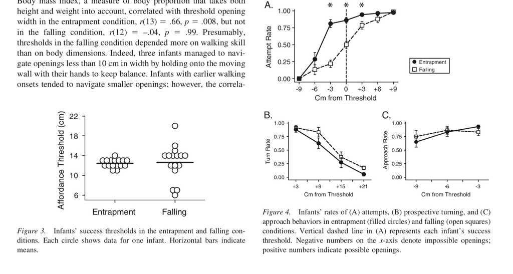

## Making effective sets of visualizations

- What makes a good series of graphs in a paper?
  - Consistency scaling across graphs
  - Same mappings for shape/color/line styles across graphs
  - Consistent graphical styles (font sizes, line weights, capitalization, etc)